# Travel_Package_Purchase_Prediction

### Background and Context

You are a Data Scientist for a tourism company named "Visit with us". The Policy Maker of the company wants to enable and establish a viable business model to expand the customer base.

A viable business model is a central concept that helps you to understand the existing ways of doing the business and how to change the ways for the benefit of the tourism sector.

One of the ways to expand the customer base is to introduce a new offering of packages.

Currently, there are 5 types of packages the company is offering - Basic, Standard, Deluxe, Super Deluxe, King. Looking at the data of the last year, we observed that 18% of the customers purchased the packages.

However, the marketing cost was quite high because customers were contacted at random without looking at the available information.

The company is now planning to launch a new product i.e. Wellness Tourism Package. Wellness Tourism is defined as Travel that allows the traveler to maintain, enhance or kick-start a healthy lifestyle, and support or increase one's sense of well-being.

However, this time company wants to harness the available data of existing and potential customers to make the marketing expenditure more efficient.

You as a Data Scientist at "Visit with us" travel company have to analyze the customers' data and information to provide recommendations to the Policy Maker and Marketing Team and also build a model to predict the potential customer who is going to purchase the newly introduced travel package.

### Objective

To predict which customer is more likely to purchase the newly introduced travel package.

#### Data Dictionary

##### Customer details:

- CustomerID: Unique customer ID
- ProdTaken: Whether the customer has purchased a package or not (0: No, 1: Yes)
- Age: Age of customer
- TypeofContact: How customer was contacted (Company Invited or Self Inquiry)
- CityTier: City tier depends on the development of a city, population, facilities, and living standards. The categories are ordered i.e. Tier 1 > Tier 2 > Tier 3
- Occupation: Occupation of customer
- Gender: Gender of customer
- NumberOfPersonVisiting: Total number of persons planning to take the trip with the customer
- PreferredPropertyStar: Preferred hotel property rating by customer
- MaritalStatus: Marital status of customer
- NumberOfTrips: Average number of trips in a year by customer
- Passport: The customer has a passport or not (0: No, 1: Yes)
- OwnCar: Whether the customers own a car or not (0: No, 1: Yes)
- NumberOfChildrenVisiting: Total number of children with age less than 5 planning to take the trip with the customer
- Designation: Designation of the customer in the current organization
- MonthlyIncome: Gross monthly income of the customer

##### Customer interaction data:

- PitchSatisfactionScore: Sales pitch satisfaction score
- ProductPitched: Product pitched by the salesperson
- NumberOfFollowups: Total number of follow-ups has been done by the salesperson after the sales pitch
- DurationOfPitch: Duration of the pitch by a salesperson to the customer

## Overview of the dataset

**Let's start by importing libraries we need.**

```python
import warnings
warnings.filterwarnings("ignore")
import numpy as np
import pandas as pd
import seaborn as sns
import matplotlib.pyplot as plt
from sklearn import metrics
from sklearn.tree import DecisionTreeClassifier
from sklearn.model_selection import train_test_split
from sklearn.metrics import confusion_matrix, classification_report
from sklearn.metrics import accuracy_score,precision_score,recall_score,f1_score
import scipy.stats as stats
from sklearn import tree
from sklearn.model_selection import GridSearchCV
from sklearn.ensemble import BaggingClassifier
from sklearn.ensemble import RandomForestClassifier
from sklearn.ensemble import StackingClassifier
from sklearn.metrics import roc_auc_score
from sklearn.linear_model import LogisticRegression
from sklearn.ensemble import AdaBoostClassifier, GradientBoostingClassifier
#To install xgboost library use - !pip install xgboost
from xgboost import XGBClassifier
#from catboost import CatBoostClassifier

# Removes the limit for the number of displayed columns
pd.set_option("display.max_columns", None)
# Sets the limit for the number of displayed rows
pd.set_option("display.max_rows", 200)
```

```python
#Loading dataset
data=pd.read_excel('Tourism.xlsx', sheet_name = 'Tourism')
```

**View the first 5 rows of the dataset.**

```python
data.head()
```

|  | CustomerID | ProdTaken | Age | TypeofContact | CityTier | DurationOfPitch | Occupation | Gender | NumberOfPersonVisiting | NumberOfFollowups | ProductPitched | PreferredPropertyStar | MaritalStatus | NumberOfTrips | Passport | PitchSatisfactionScore | OwnCar | NumberOfChildrenVisiting | Designation | MonthlyIncome |
| --- | --- | --- | --- | --- | --- | --- | --- | --- | --- | --- | --- | --- | --- | --- | --- | --- | --- | --- | --- | --- |
| 0 | 200000 | 1 | 41.0 | Self Enquiry | 3 | 6.0 | Salaried | Female | 3 | 3.0 | Deluxe | 3.0 | Single | 1.0 | 1 | 2 | 1 | 0.0 | Manager | 20993.0 |
| 1 | 200001 | 0 | 49.0 | Company Invited | 1 | 14.0 | Salaried | Male | 3 | 4.0 | Deluxe | 4.0 | Divorced | 2.0 | 0 | 3 | 1 | 2.0 | Manager | 20130.0 |
| 2 | 200002 | 1 | 37.0 | Self Enquiry | 1 | 8.0 | Free Lancer | Male | 3 | 4.0 | Basic | 3.0 | Single | 7.0 | 1 | 3 | 0 | 0.0 | Executive | 17090.0 |
| 3 | 200003 | 0 | 33.0 | Company Invited | 1 | 9.0 | Salaried | Female | 2 | 3.0 | Basic | 3.0 | Divorced | 2.0 | 1 | 5 | 1 | 1.0 | Executive | 17909.0 |
| 4 | 200004 | 0 | NaN | Self Enquiry | 1 | 8.0 | Small Business | Male | 2 | 3.0 | Basic | 4.0 | Divorced | 1.0 | 0 | 5 | 1 | 0.0 | Executive | 18468.0 |

**Check data types and number of non-null values for each column.**

```python
data.info()
```

```
<class 'pandas.core.frame.DataFrame'>
RangeIndex: 4888 entries, 0 to 4887
Data columns (total 20 columns):
 #   Column                    Non-Null Count  Dtype
---  ------                    --------------  -----
 0   CustomerID                4888 non-null   int64
 1   ProdTaken                 4888 non-null   int64
 2   Age                       4662 non-null   float64
 3   TypeofContact             4863 non-null   object
 4   CityTier                  4888 non-null   int64
 5   DurationOfPitch           4637 non-null   float64
 6   Occupation                4888 non-null   object
 7   Gender                    4888 non-null   object
 8   NumberOfPersonVisiting    4888 non-null   int64
 9   NumberOfFollowups         4843 non-null   float64
 10  ProductPitched            4888 non-null   object
 11  PreferredPropertyStar     4862 non-null   float64
 12  MaritalStatus             4888 non-null   object
 13  NumberOfTrips             4748 non-null   float64
 14  Passport                  4888 non-null   int64
 15  PitchSatisfactionScore    4888 non-null   int64
 16  OwnCar                    4888 non-null   int64
 17  NumberOfChildrenVisiting  4822 non-null   float64
 18  Designation               4888 non-null   object
 19  MonthlyIncome             4655 non-null   float64
dtypes: float64(7), int64(7), object(6)
memory usage: 763.9+ KB
```

- We can see that there are total of 20 columns and 4,888 rows in the dataset.
- All columns data type is either integer ,float or the object type.
- There are null values in the dataset

```python
data.isna().sum()
```

```
CustomerID                    0
ProdTaken                     0
Age                         226
TypeofContact                25
CityTier                      0
DurationOfPitch             251
Occupation                    0
Gender                        0
NumberOfPersonVisiting        0
NumberOfFollowups            45
ProductPitched                0
PreferredPropertyStar        26
MaritalStatus                 0
NumberOfTrips               140
Passport                      0
PitchSatisfactionScore        0
OwnCar                        0
NumberOfChildrenVisiting     66
Designation                   0
MonthlyIncome               233
dtype: int64
```

- There are missing values in the data

**Check duplicates Count**

```python
data.drop(['CustomerID'], axis=1).duplicated().sum()
```

```
141
```

- Dataset contains 141 duplicates

**Show duplicated rows**

```python
data[data.drop(['CustomerID'], axis=1).duplicated(keep=False)].sort_values(by = 'MonthlyIncome')
```

|  | CustomerID | ProdTaken | Age | TypeofContact | CityTier | DurationOfPitch | Occupation | Gender | NumberOfPersonVisiting | NumberOfFollowups | ProductPitched | PreferredPropertyStar | MaritalStatus | NumberOfTrips | Passport | PitchSatisfactionScore | OwnCar | NumberOfChildrenVisiting | Designation | MonthlyIncome |
| --- | --- | --- | --- | --- | --- | --- | --- | --- | --- | --- | --- | --- | --- | --- | --- | --- | --- | --- | --- | --- |
| 1971 | 201971 | 0 | 30.0 | Company Invited | 1 | 9.0 | Small Business | Female | 3 | 3.0 | Basic | 3.0 | Married | 2.0 | 0 | 3 | 1 | 1.0 | Executive | 17083.0 |
| 501 | 200501 | 0 | 30.0 | Company Invited | 1 | 9.0 | Small Business | Female | 3 | 3.0 | Basic | 3.0 | Married | 2.0 | 0 | 3 | 1 | 1.0 | Executive | 17083.0 |
| 1642 | 201642 | 0 | 36.0 | Company Invited | 1 | 9.0 | Small Business | Male | 1 | 3.0 | Basic | 4.0 | Single | 5.0 | 0 | 4 | 1 | 0.0 | Executive | 17088.0 |
| 172 | 200172 | 0 | 36.0 | Company Invited | 1 | 9.0 | Small Business | Male | 1 | 3.0 | Basic | 4.0 | Single | 5.0 | 0 | 4 | 1 | 0.0 | Executive | 17088.0 |
| 1732 | 201732 | 0 | 32.0 | Self Enquiry | 1 | 8.0 | Large Business | Male | 2 | 4.0 | Deluxe | 5.0 | Single | 5.0 | 0 | 4 | 0 | 1.0 | Manager | 17176.0 |
| ... | ... | ... | ... | ... | ... | ... | ... | ... | ... | ... | ... | ... | ... | ... | ... | ... | ... | ... | ... | ... |
| 2093 | 202093 | 0 | NaN | Company Invited | 1 | 11.0 | Salaried | Male | 3 | 4.0 | Basic | 3.0 | Married | 1.0 | 0 | 5 | 0 | 0.0 | Executive | NaN |
| 2189 | 202189 | 0 | NaN | Self Enquiry | 3 | 10.0 | Salaried | Female | 2 | 3.0 | Deluxe | 3.0 | Single | 2.0 | 1 | 3 | 1 | 1.0 | Manager | NaN |
| 2195 | 202195 | 1 | NaN | Self Enquiry | 1 | 20.0 | Salaried | Male | 2 | 4.0 | Basic | 4.0 | Married | 2.0 | 1 | 5 | 1 | 1.0 | Executive | NaN |
| 2237 | 202237 | 0 | NaN | Self Enquiry | 1 | 9.0 | Salaried | Female | 2 | 3.0 | Deluxe | 4.0 | Single | 4.0 | 0 | 4 | 1 | 0.0 | Manager | NaN |
| 2305 | 202305 | 0 | 35.0 | Self Enquiry | 2 | NaN | Large Business | Male | 3 | 3.0 | Basic | 3.0 | Single | 2.0 | 0 | 5 | 0 | 1.0 | Executive | NaN |

282 rows × 20 columns

### Removing Duplicated Rows

```python
data.drop(index = data[data.drop(['CustomerID'], axis=1).duplicated()].index.values, axis=0, inplace=True)
```

### Fixing the data types

```python
cols = data.select_dtypes(['object'])
cols.columns
```

```
Index(['TypeofContact', 'Occupation', 'Gender', 'ProductPitched',
       'MaritalStatus', 'Designation'],
      dtype='object')
```

```python
for i in cols.columns:
    data[i] = data[i].astype('category')
```

```python
data.info()
```

```
<class 'pandas.core.frame.DataFrame'>
Int64Index: 4747 entries, 0 to 4887
Data columns (total 20 columns):
 #   Column                    Non-Null Count  Dtype
---  ------                    --------------  -----
 0   CustomerID                4747 non-null   int64
 1   ProdTaken                 4747 non-null   int64
 2   Age                       4531 non-null   float64
 3   TypeofContact             4722 non-null   category
 4   CityTier                  4747 non-null   int64
 5   DurationOfPitch           4501 non-null   float64
 6   Occupation                4747 non-null   category
 7   Gender                    4747 non-null   category
 8   NumberOfPersonVisiting    4747 non-null   int64
 9   NumberOfFollowups         4703 non-null   float64
 10  ProductPitched            4747 non-null   category
 11  PreferredPropertyStar     4721 non-null   float64
 12  MaritalStatus             4747 non-null   category
 13  NumberOfTrips             4609 non-null   float64
 14  Passport                  4747 non-null   int64
 15  PitchSatisfactionScore    4747 non-null   int64
 16  OwnCar                    4747 non-null   int64
 17  NumberOfChildrenVisiting  4687 non-null   float64
 18  Designation               4747 non-null   category
 19  MonthlyIncome             4523 non-null   float64
dtypes: category(6), float64(7), int64(7)
memory usage: 585.2 KB
```

**Summary of the dataset**

```python
# Summary of continuous columns
data.select_dtypes(['float64', 'int64']).describe().T
```

|  | count | mean | std | min | 25% | 50% | 75% | max |
| --- | --- | --- | --- | --- | --- | --- | --- | --- |
| CustomerID | 4747.0 | 202421.241416 | 1409.744061 | 200000.0 | 201186.5 | 202443.0 | 203629.5 | 204887.0 |
| ProdTaken | 4747.0 | 0.188329 | 0.391016 | 0.0 | 0.0 | 0.0 | 0.0 | 1.0 |
| Age | 4531.0 | 37.585522 | 9.328723 | 18.0 | 31.0 | 36.0 | 44.0 | 61.0 |
| CityTier | 4747.0 | 1.655151 | 0.917416 | 1.0 | 1.0 | 1.0 | 3.0 | 3.0 |
| DurationOfPitch | 4501.0 | 15.510998 | 8.535634 | 5.0 | 9.0 | 13.0 | 20.0 | 127.0 |
| NumberOfPersonVisiting | 4747.0 | 2.911734 | 0.724040 | 1.0 | 2.0 | 3.0 | 3.0 | 5.0 |
| NumberOfFollowups | 4703.0 | 3.705082 | 1.008677 | 1.0 | 3.0 | 4.0 | 4.0 | 6.0 |
| PreferredPropertyStar | 4721.0 | 3.583351 | 0.800351 | 3.0 | 3.0 | 3.0 | 4.0 | 5.0 |
| NumberOfTrips | 4609.0 | 3.233239 | 1.847851 | 1.0 | 2.0 | 3.0 | 4.0 | 22.0 |
| Passport | 4747.0 | 0.289657 | 0.453651 | 0.0 | 0.0 | 0.0 | 1.0 | 1.0 |
| PitchSatisfactionScore | 4747.0 | 3.051612 | 1.369584 | 1.0 | 2.0 | 3.0 | 4.0 | 5.0 |
| OwnCar | 4747.0 | 0.617653 | 0.486012 | 0.0 | 0.0 | 1.0 | 1.0 | 1.0 |
| NumberOfChildrenVisiting | 4687.0 | 1.193514 | 0.860461 | 0.0 | 1.0 | 1.0 | 2.0 | 3.0 |
| MonthlyIncome | 4523.0 | 23602.239443 | 5385.503223 | 1000.0 | 20337.0 | 22311.0 | 25535.5 | 98678.0 |

- The mean and median value of `NumberOfPersonVisiting` is approx 2.9 and 3.0 respectively
- The mean and median value for `NumberOfFollowups` is approx 3.7 and 4.0 respectively
- `DurationOfPitch` seems to have skewed distribution as higher values are on the right. We will explore this further.
- `NumberOfTrips` seems to have skewed distribution as higher values are on the right. We will explore this further.
- `MonthlyIncome` seems to have skewed distribution as higher values are on the right. We will explore this further.

**Number of unique values in each column**

```python
data.nunique()
```

```
CustomerID                  4747
ProdTaken                      2
Age                           44
TypeofContact                  2
CityTier                       3
DurationOfPitch               34
Occupation                     4
Gender                         3
NumberOfPersonVisiting         5
NumberOfFollowups              6
ProductPitched                 5
PreferredPropertyStar          3
MaritalStatus                  4
NumberOfTrips                 12
Passport                       2
PitchSatisfactionScore         5
OwnCar                         2
NumberOfChildrenVisiting       4
Designation                    5
MonthlyIncome               2475
dtype: int64
```

- We can drop 'CustomerID' column as it is an ID variable and will not add value to the model.

```python
#Dropping two columns from the dataframe
data.drop(columns=['CustomerID'], inplace=True)
```

**Number of observations in each category**

```python
cat_cols = data.select_dtypes(['category']).columns.to_list()

for column in cat_cols:
    print(data[column].value_counts())
    print('-'*30)
```

```
Self Enquiry       3350
Company Invited    1372
Name: TypeofContact, dtype: int64
------------------------------
Salaried          2293
Small Business    2028
Large Business     424
Free Lancer          2
Name: Occupation, dtype: int64
------------------------------
Male       2835
Female     1769
Fe Male     143
Name: Gender, dtype: int64
------------------------------
Basic           1800
Deluxe          1684
Standard         714
Super Deluxe     324
King             225
Name: ProductPitched, dtype: int64
------------------------------
Married      2279
Divorced      950
Single        875
Unmarried     643
Name: MaritalStatus, dtype: int64
------------------------------
Executive         1800
Manager           1684
Senior Manager     714
AVP                324
VP                 225
Name: Designation, dtype: int64
------------------------------
```

- 'Female' and 'Fe Male' are equivalent in `Gender`. This will be adjusted

### Fixing the Gender

```python
data.Gender = ['Female' if i == 'Fe Male' else i for i in data.Gender]
```

```python
# Confirmation of the Fix

data.Gender.value_counts()
```

```
Male      2835
Female    1912
Name: Gender, dtype: int64
```

## EDA

### Univariate analysis

```python
# function to plot a boxplot and a histogram along the same scale.


def histogram_boxplot(data, feature, figsize=(12, 7), kde=False, bins=None):
    """
    Boxplot and histogram combined

    data: dataframe
    feature: dataframe column
    figsize: size of figure (default (12,7))
    kde: whether to show the density curve (default False)
    bins: number of bins for histogram (default None)
    """
    f2, (ax_box2, ax_hist2) = plt.subplots(
        nrows=2,  # Number of rows of the subplot grid= 2
        sharex=True,  # x-axis will be shared among all subplots
        gridspec_kw={"height_ratios": (0.25, 0.75)},
        figsize=figsize,
    )  # creating the 2 subplots
    sns.boxplot(
        data=data, x=feature, ax=ax_box2, showmeans=True, color="violet"
    )  # boxplot will be created and a star will indicate the mean value of the column
    sns.histplot(
        data=data, x=feature, kde=kde, ax=ax_hist2, bins=bins, palette="winter"
    ) if bins else sns.histplot(
        data=data, x=feature, kde=kde, ax=ax_hist2
    )  # For histogram
    ax_hist2.axvline(
        data[feature].mean(), color="green", linestyle="--"
    )  # Add mean to the histogram
    ax_hist2.axvline(
        data[feature].median(), color="black", linestyle="-"
    )  # Add median to the histogram
```

**Observations on Age**

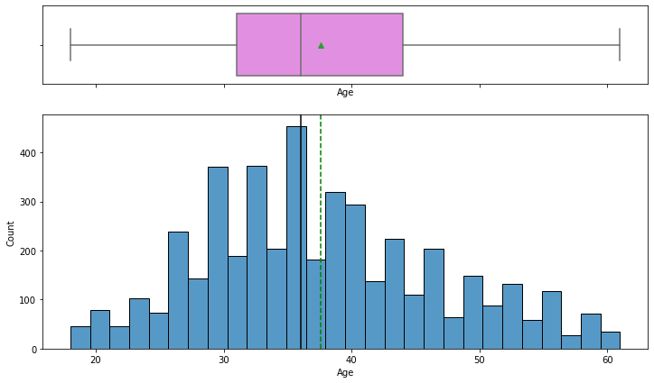

```python
histogram_boxplot(data, "Age")
```

- `Age` looks normally distributed

**Observations on DurationOfPitch**

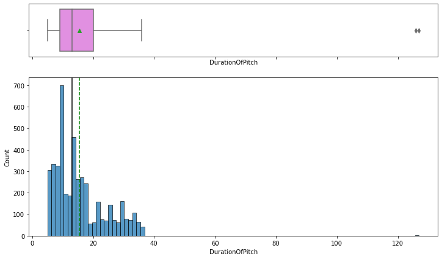

```python
histogram_boxplot(data, "DurationOfPitch")
```

- `DurationOfPitch` looks right skewed with extreme outliers

**Observations on Logarihmic DurationOfPitch**

```python
# Log Scale for duration on Pitch
data['DurationOfPitch_log'] = np.log(data.DurationOfPitch + 1)
```

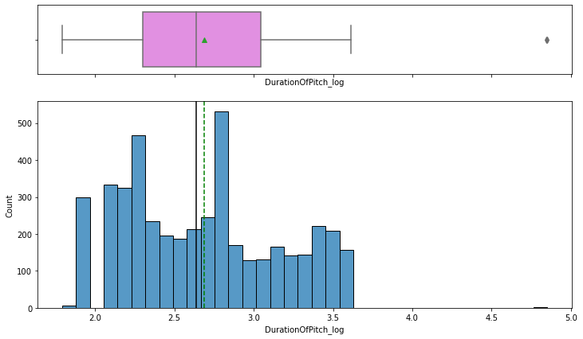

```python
histogram_boxplot(data, "DurationOfPitch_log")
```

- `DurationOfPitch` now has a more balanced distribution on the Logarithmic Scale

**Observations on NumberOfPersonVisiting**

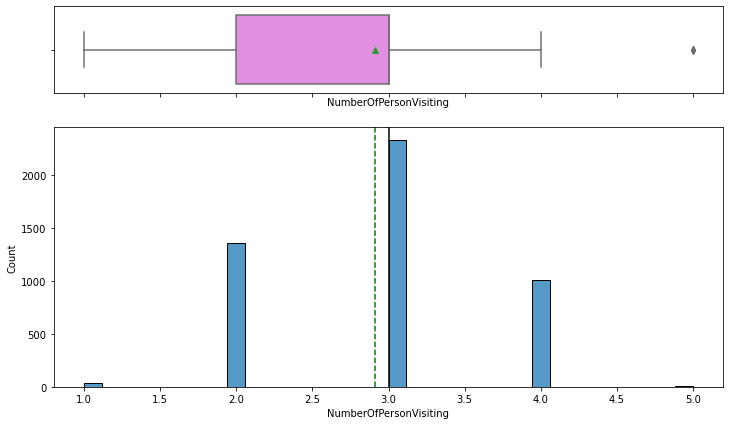

```python
histogram_boxplot(data, "NumberOfPersonVisiting")
```

- `NumberOfPersonVisiting`looks normally distributed

**Observations on NumberOfFollowups**

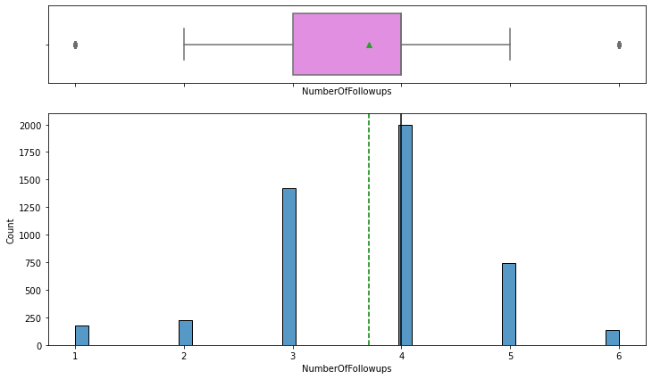

```python
histogram_boxplot(data, "NumberOfFollowups")
```

- `NumberOfFollowups` looks normally distributed

**Observations on NumberOfTrips**

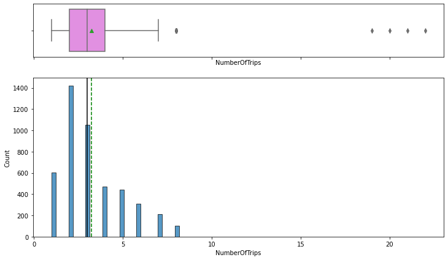

```python
histogram_boxplot(data, "NumberOfTrips")
```

- `NumberOfTrips` is skewed to the right with outliers

**Observations on Logarihmic NumberOfTrips**

```python
# Log Scale for duration on Pitch
data['NumberOfTrips_log'] = np.log(data.NumberOfTrips + 1)
```

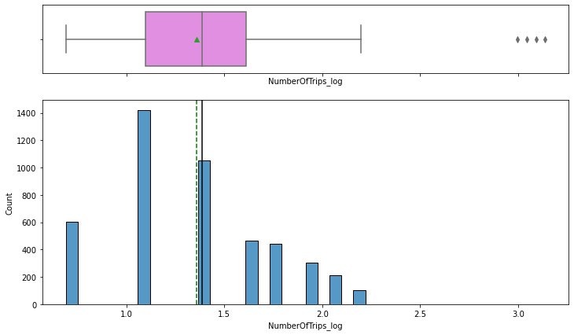

```python
histogram_boxplot(data, "NumberOfTrips_log")
```

- `NumberOfTrips` now has a more balanced distribution on the Logarithmic Scale

**Observations on NumberOfChildrenVisiting**

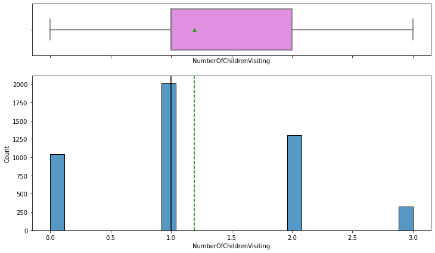

```python
histogram_boxplot(data, "NumberOfChildrenVisiting")
```

- `NumberOfChildrenVisiting`looks normally distributed

**Observations on MonthlyIncome**

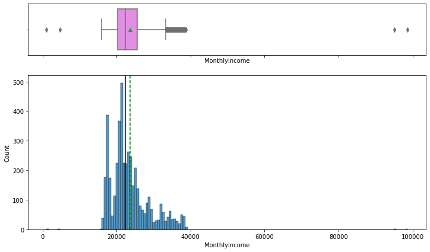

```python
histogram_boxplot(data, "MonthlyIncome")
```

**Observations on Logarihmic MonthlyIncome**

```python
# Log Scale for duration on Pitch
data['MonthlyIncome_log'] = np.log(data.MonthlyIncome + 1)
```

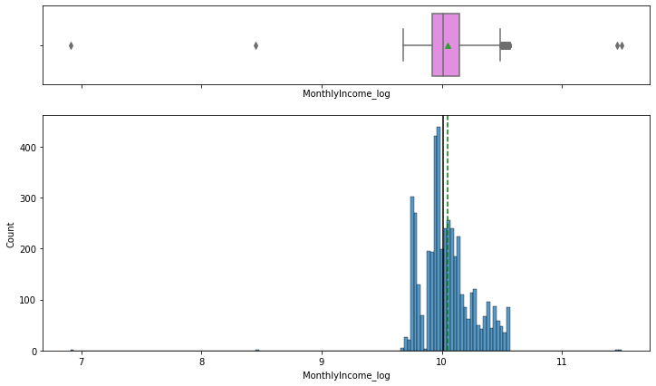

```python
histogram_boxplot(data, "MonthlyIncome_log")
```

- `MonthlyIncome` has a more balanced distribution on the Logarithmic Scale

**Function to create barplots that indicate percentage for each category**

```python
# function to create labeled barplots


def labeled_barplot(data, feature, perc=False, n=None):
    """
    Barplot with percentage at the top

    data: dataframe
    feature: dataframe column
    perc: whether to display percentages instead of count (default is False)
    n: displays the top n category levels (default is None, i.e., display all levels)
    """

    total = len(data[feature])  # length of the column
    count = data[feature].nunique()
    if n is None:
        plt.figure(figsize=(count + 1, 5))
    else:
        plt.figure(figsize=(n + 1, 5))

    plt.xticks(rotation=90, fontsize=15)
    ax = sns.countplot(
        data=data,
        x=feature,
        palette="Paired",
        order=data[feature].value_counts().index[:n].sort_values(),
    )

    for p in ax.patches:
        if perc == True:
            label = "{:.1f}%".format(
                100 * p.get_height() / total
            )  # percentage of each class of the category
        else:
            label = p.get_height()  # count of each level of the category

        x = p.get_x() + p.get_width() / 2  # width of the plot
        y = p.get_height()  # height of the plot

        ax.annotate(
            label,
            (x, y),
            ha="center",
            va="center",
            size=12,
            xytext=(0, 5),
            textcoords="offset points",
        )  # annotate the percentage

    plt.show()  # show the plot
```

**Observations on TypeofContact**

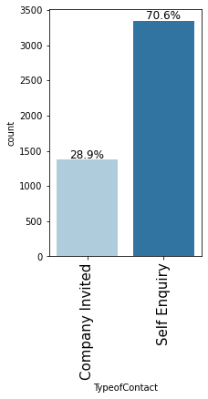

```python
labeled_barplot(data, "TypeofContact",perc=True)
```

- Most of the contacts reached by the company was from Self Enquiry

**Observations on Occupation**

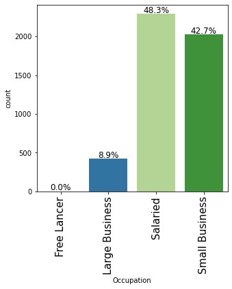

```python
labeled_barplot(data, "Occupation",perc=True)
```

- An insignificant amount of Customers are Free Lancers
- Most Customers earn salaries or have small businesses. This could explain why there are few high income earners compared to averge income earners

**Observations on ProductPitched**

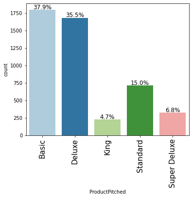

```python
labeled_barplot(data, "ProductPitched",perc=True)
```

- Most of the contacts reached by the company were presented with the Basic and Deluxe Package

**Observations on MaritalStatus**

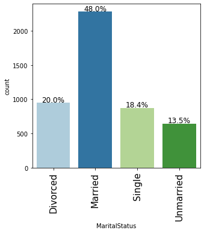

```python
labeled_barplot(data, "MaritalStatus",perc=True)
```

- Most of the contacts reached by the company are married

**Observations on Designation**

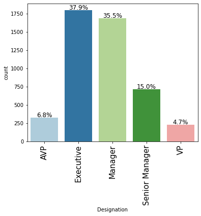

```python
labeled_barplot(data, "Designation",perc=True)
```

- Most of the contacts reached by the company were executives and Managers

**Observations on CityTier**

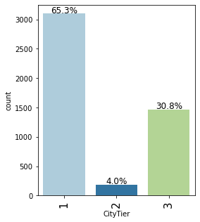

```python
labeled_barplot(data, "CityTier",perc=True)
```

- Most of the contacts reached by the company were from Tier 1.
- The company is more interested in customers with highwr living standards

**Observations on PreferredPropertyStar**

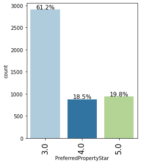

```python
labeled_barplot(data, "PreferredPropertyStar",perc=True)
```

- Most of the customers prefer hotels with Rating 3

**Observations on PitchSatisfactionScore**

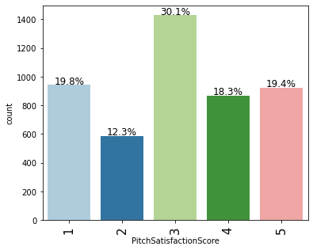

```python
labeled_barplot(data, "PitchSatisfactionScore",perc=True)
```

- Most of the sales pitch satisfaction score was average

**Observations on Gender**

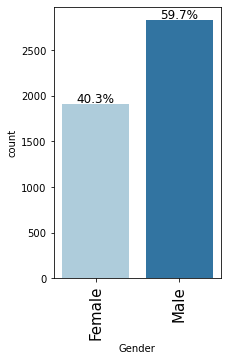

```python
labeled_barplot(data, "Gender",perc=True)
```

- Most of the customers pitched to were male

### Bivariate analysis

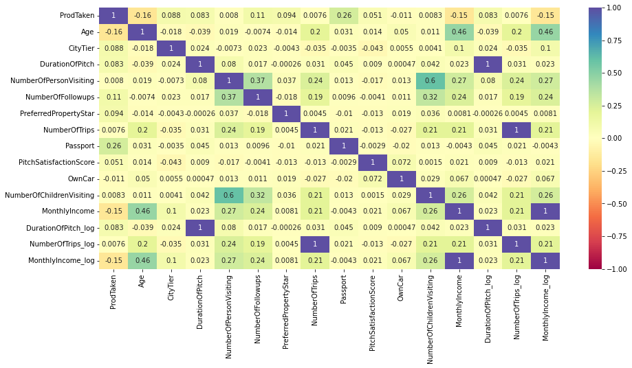

```python
plt.figure(figsize=(15, 7))
sns.heatmap(data.corr(method = 'spearman'), annot=True, vmin=-1, vmax=1, cmap="Spectral")
plt.show()
```

- The variable are not well correlated with one another
- There is a weak negative relationship betweeen customer choice of product with the Age and Monthly Income

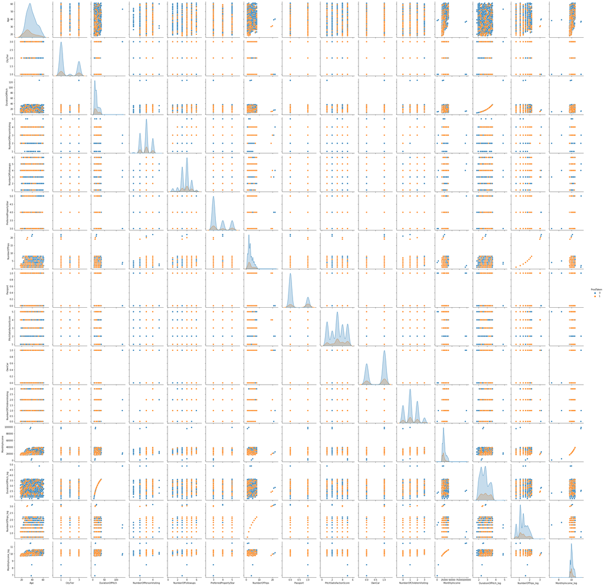

```python
sns.pairplot(data=data, hue="ProdTaken")
plt.show()
```

### ProdTaken vs Numerical variables

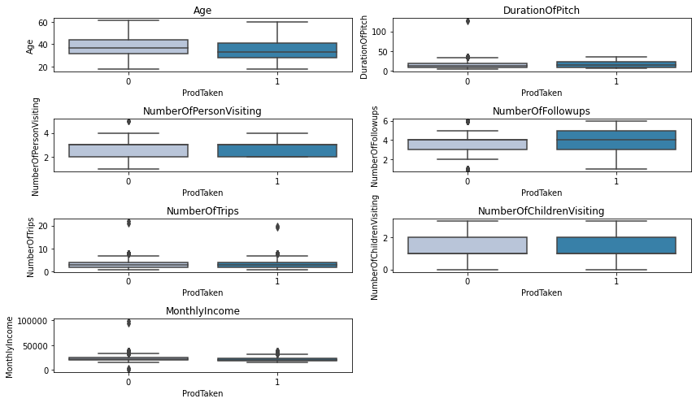

```python
cols = data[
    [
        'Age',
        'DurationOfPitch',
        'NumberOfPersonVisiting',
        'NumberOfFollowups',
        'NumberOfTrips',
        'NumberOfChildrenVisiting',
        'MonthlyIncome'
    ]
].columns.tolist()
plt.figure(figsize=(12, 7))

for i, variable in enumerate(cols):
    plt.subplot(4, 2, i + 1)
    sns.boxplot(data["ProdTaken"], data[variable], palette="PuBu")
    plt.tight_layout()
    plt.title(variable)
plt.show()
```

**It is difficult to make an interpretation from the graphs above let's visualize them by removing these outliers (for visualization not from orignal data) to get a better understanding**

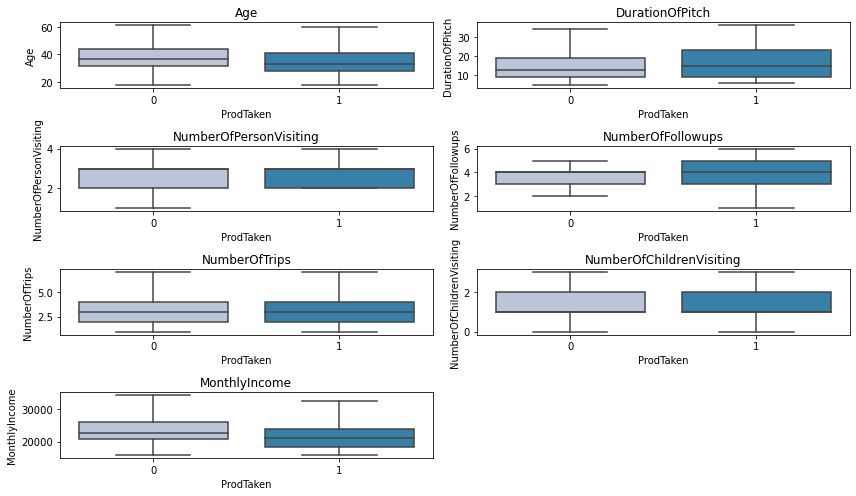

```python
cols = data[
    [
        'Age',
        'DurationOfPitch',
        'NumberOfPersonVisiting',
        'NumberOfFollowups',
        'NumberOfTrips',
        'NumberOfChildrenVisiting',
        'MonthlyIncome'
    ]
].columns.tolist()
plt.figure(figsize=(12, 7))

for i, variable in enumerate(cols):
    plt.subplot(4, 2, i + 1)
    sns.boxplot(data["ProdTaken"], data[variable], palette="PuBu", showfliers=False)
    plt.tight_layout()
    plt.title(variable)
plt.show()
```

- Customers who are older are more likely to turn down the Product offered compared to the younger ones.
- Customers with lower monthly income are likely to take an offer compared to those with higher income
- Customers with higher follow ups are more likely to take an offer compared to those with lower follow ups.
- Customers with lower pitch time are likely to turn down the product offered compared to those with higher pitch time.
- There is no clear distinction based on Number of persons visiting, number of trips, and number of children visiting

```python
# function to plot stacked bar chart


def stacked_barplot(data, predictor, target):
    """
    Print the category counts and plot a stacked bar chart

    data: dataframe
    predictor: independent variable
    target: target variable
    """
    count = data[predictor].nunique()
    sorter = data[target].value_counts().index[-1]
    tab1 = pd.crosstab(data[predictor], data[target], margins=True).sort_values(
        by=sorter, ascending=False
    )
    print(tab1)
    print("-" * 120)
    tab = pd.crosstab(data[predictor], data[target], normalize="index").sort_values(
        by=sorter, ascending=False
    )
    tab.plot(kind="bar", stacked=True, figsize=(count + 5, 6))
    plt.legend(
        loc="lower left", frameon=False,
    )
    plt.legend(loc="upper left", bbox_to_anchor=(1, 1))
    plt.show()
```

### ProdTaken vs TypeofContact

```
ProdTaken           0    1   All
TypeofContact
All              3831  891  4722
Self Enquiry     2753  597  3350
Company Invited  1078  294  1372
------------------------------------------------------------------------------------------------------------------------
```

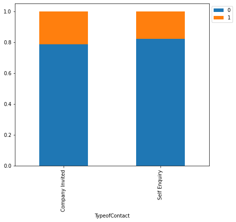

```python
stacked_barplot(data, "TypeofContact", "ProdTaken")
```

- Although coustomers with self inquiry is the largest contributor to product taken, company invited customers are mosre like to take an offer for the product

### ProdTaken vs Occupation

```
ProdTaken          0    1   All
Occupation
All             3853  894  4747
Salaried        1893  400  2293
Small Business  1654  374  2028
Large Business   306  118   424
Free Lancer        0    2     2
------------------------------------------------------------------------------------------------------------------------
```

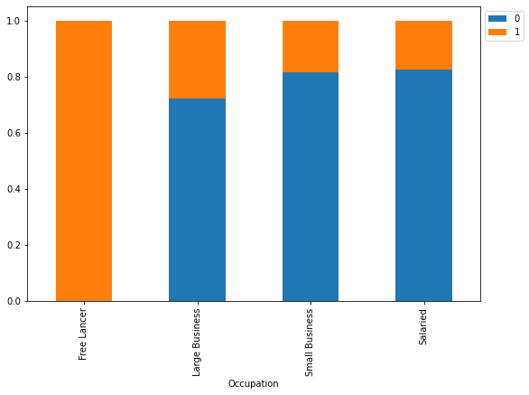

```python
stacked_barplot(data, "Occupation", "ProdTaken")
```

- All freelancers took an offer. However, the number is highly insignificant
- Though the smallest contributor after freelancers, customers here are most likely to take a product when offered comppared to Small Businesses or Salaries.

### ProdTaken vs ProductPitched

```
ProdTaken          0    1   All
ProductPitched
All             3853  894  4747
Basic           1260  540  1800
Deluxe          1486  198  1684
Standard         594  120   714
King             205   20   225
Super Deluxe     308   16   324
------------------------------------------------------------------------------------------------------------------------
```

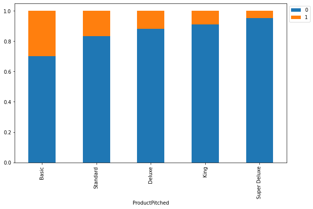

```python
stacked_barplot(data, "ProductPitched", "ProdTaken")
```

- As expected, most of those who took the offer were from the basic package
- The least willing customers to take an offer were pitched the Super Deluxe Package

### ProdTaken vs MaritalStatus

```
ProdTaken         0    1   All
MaritalStatus
All            3853  894  4747
Married        1965  314  2279
Single          578  297   875
Unmarried       484  159   643
Divorced        826  124   950
------------------------------------------------------------------------------------------------------------------------
```

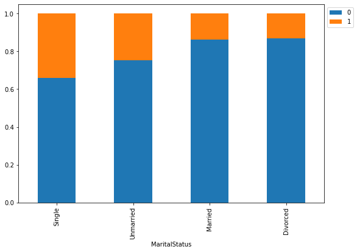

```python
stacked_barplot(data, "MaritalStatus", "ProdTaken")
```

- Although Married customers had the largest contribution to the count of product takers, singles customers are more likely to take an offer for a product

### ProdTaken vs Gender

```
ProdTaken     0    1   All
Gender
All        3853  894  4747
Male       2273  562  2835
Female     1580  332  1912
------------------------------------------------------------------------------------------------------------------------
```

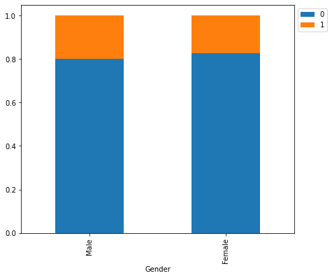

```python
stacked_barplot(data, "Gender", "ProdTaken")
```

- Although Males have the highest contribution to product takers, there is no significant difference between be the response to the product pitch based on the genders

### ProdTaken vs Designation

```
ProdTaken          0    1   All
Designation
All             3853  894  4747
Executive       1260  540  1800
Manager         1486  198  1684
Senior Manager   594  120   714
VP               205   20   225
AVP              308   16   324
------------------------------------------------------------------------------------------------------------------------
```

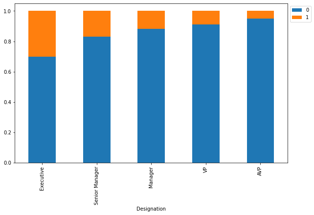

```python
stacked_barplot(data, "Designation", "ProdTaken")
```

- Executive customers are most likely to take the product

### ProdTaken vs CityTier

```
ProdTaken     0    1   All
CityTier
All        3853  894  4747
1          2592  506  3098
3          1115  346  1461
2           146   42   188
------------------------------------------------------------------------------------------------------------------------
```

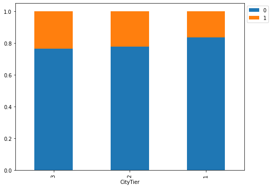

```python
stacked_barplot(data, "CityTier", "ProdTaken")
```

- Tier 1 customers are least likely to take the product.
- There is no significant difference between Tier 2 and 3 customers who are most likely to take the product

### ProdTaken vs PreferredPropertyStar

```
ProdTaken                 0    1   All
PreferredPropertyStar
All                    3833  888  4721
3.0                    2435  470  2905
5.0                     696  242   938
4.0                     702  176   878
------------------------------------------------------------------------------------------------------------------------
```

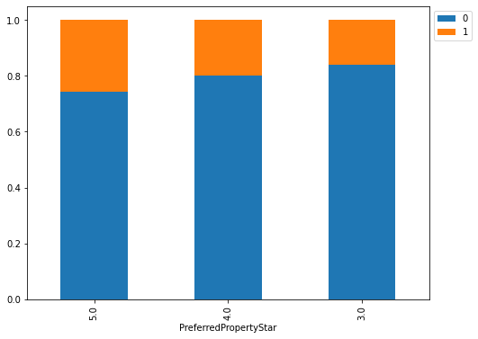

```python
stacked_barplot(data, "PreferredPropertyStar", "ProdTaken")
```

- Hotel property 5 customers are most likely to take the product

### ProdTaken vs PitchSatisfactionScore

```
ProdTaken                  0    1   All
PitchSatisfactionScore
All                     3853  894  4747
3                       1123  304  1427
5                        725  198   923
4                        709  160   869
1                        798  144   942
2                        498   88   586
------------------------------------------------------------------------------------------------------------------------
```

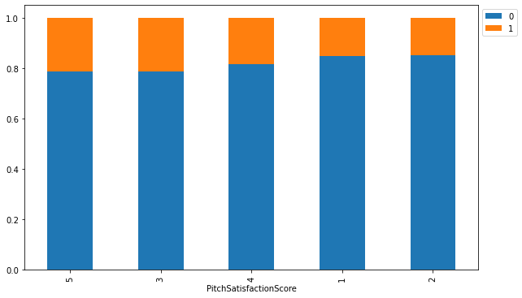

```python
stacked_barplot(data, "PitchSatisfactionScore", "ProdTaken")
```